# IODS course project

## 4) Distribution of the chosen variables and their relationships with alcohol consumption

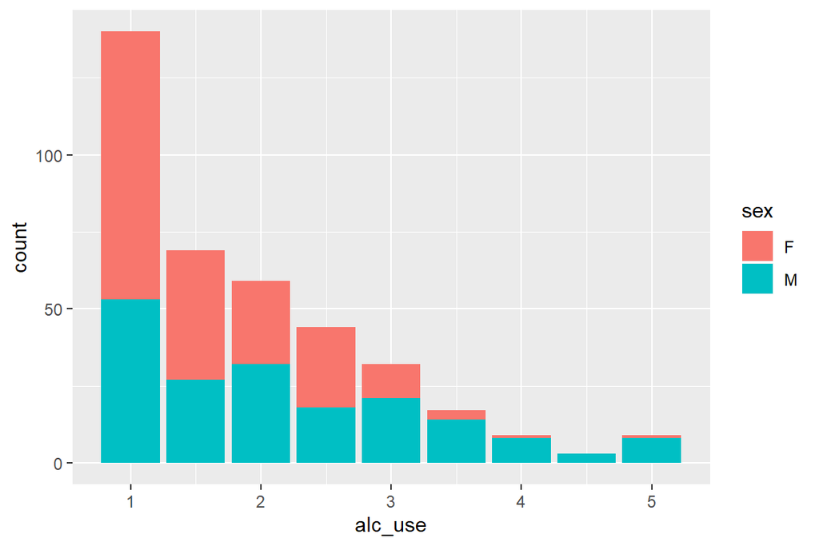

```r
g1 <- ggplot(data = alc, aes(x = alc_use, fill = sex))
g1 + geom_bar()
```

“In the first plot i have combines the alcohol usage mean from weekend and weekdays and gender. From the first plot, we can see that the hypothesis made earlier is rather true with this data. As we can see that when the alcohol consumption rises, the Male group takes the dominant portion of the group. From this it looks like Men have a higher tendency to drink more than Women”

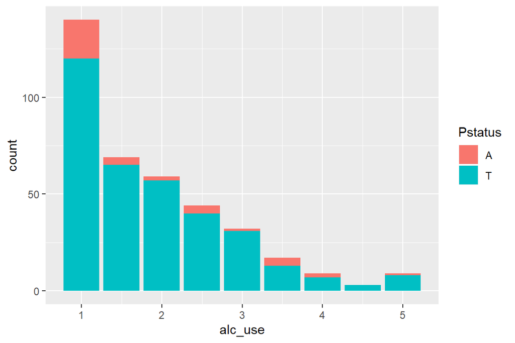

```r
g2 <- ggplot(data = alc, aes(x = alc_use, fill = Pstatus ))
g2 + geom_bar()
```

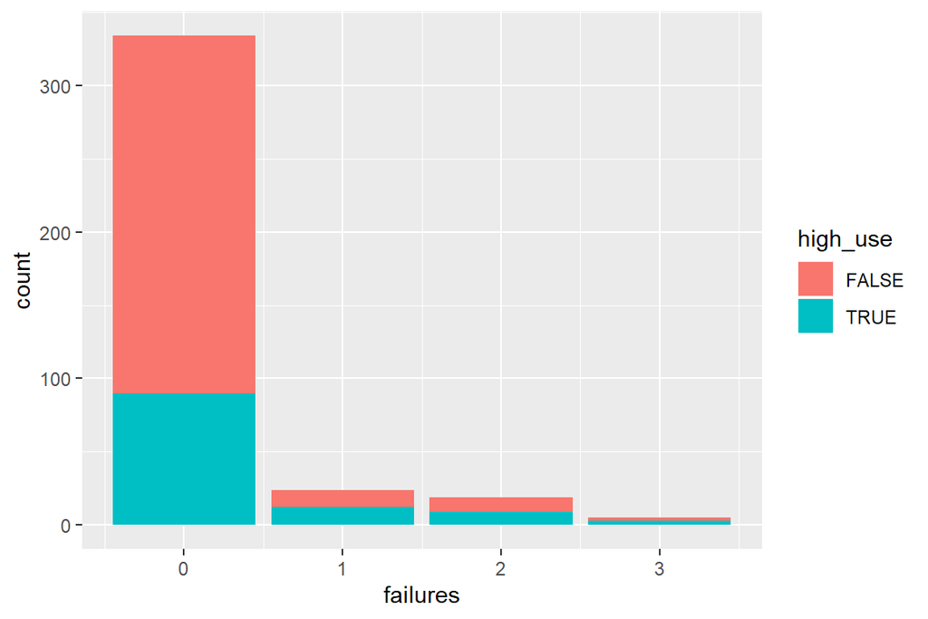

```r
g3 <- ggplot(data = alc, aes(x = failures, fill = high_use))
g3 + geom_bar()
```

“In the third plot we have the participants divided to groups by how many class failures they ve had recently and have examined the alcohol usage of these groups. In this plot I have used the high use variable, which is a binary variable that is TRUE if the pariticipants alcohol consumption is high and false if it is low or very low. From this it looks like only small proportion of the participants have failed classes recently. It also seems that in the groups with more failures also alcohol usage is higher.”

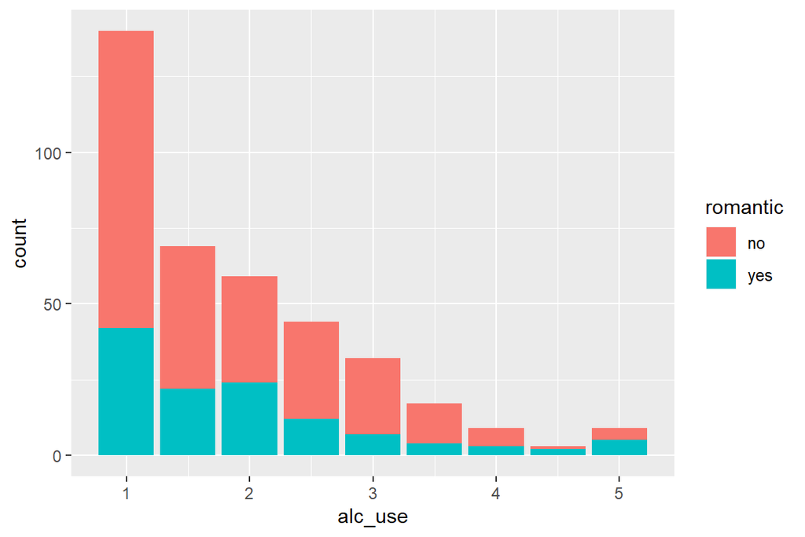

```r
g4 <- ggplot(data = alc, aes(x = alc_use, fill = romantic ))
g4 + geom_bar()
```

“In the last plot i have combined the relationship status with alcohol consumption. From this picture it seems that a major part of the participants are not in a romantic relationship. It also seems that participants who are in romantic relationship also have lower alcohol usage”

## 5) Logistic regression

```r
m <- glm(high_use ~ failures + romantic + Pstatus + sex, data = alc, family = "binomial")

summary(m)
```

```
##
## Call:
## glm(formula = high_use ~ failures + romantic + Pstatus + sex,
##     family = "binomial", data = alc)
##
## Deviance Residuals:
##     Min       1Q   Median       3Q      Max
## -1.5880  -0.9018  -0.6729   1.3436   1.8502
##
## Coefficients:
##             Estimate Std. Error z value Pr(>|z|)
## (Intercept)  -1.2055     0.3925  -3.071 0.002134 **
## failures      0.4917     0.1858   2.646 0.008147 **
## romanticyes  -0.1423     0.2521  -0.565 0.572341
## PstatusT     -0.1648     0.3798  -0.434 0.664409
## sexM          0.8228     0.2334   3.526 0.000423 ***
## ---
## Signif. codes:  0 '***' 0.001 '**' 0.01 '*' 0.05 '.' 0.1 ' ' 1
##
## (Dispersion parameter for binomial family taken to be 1)
##
##     Null deviance: 465.68  on 381  degrees of freedom
## Residual deviance: 443.46  on 377  degrees of freedom
## AIC: 453.46
##
## Number of Fisher Scoring iterations: 4
```

"Above I have made the logistic regression model with 4 explanatory variables (failures, romantic, Pstatus and sex) and high alcohol usage as the explained variable

```r
OR <- coef(m) %>% exp
CI <- confint(m) %>% exp
cbind(OR, CI)
```

```
##                    OR     2.5 %    97.5 %
## (Intercept) 0.2995552 0.1342192 0.6321402
## failures    1.6350439 1.1398169 2.3760837
## romanticyes 0.8673185 0.5249864 1.4139751
## PstatusT    0.8480771 0.4100232 1.8396731
## sexM        2.2769725 1.4465191 3.6171882
```

“Above we can see the confidence interlwalls and Odds ratios (OR). From this the two variables with significance were gender and failures. Those that fail have 1,6 x higher chance for high alcohol usage and men have 2,3 x higher chance for high alcohol usage”

## 6) Prection analysis

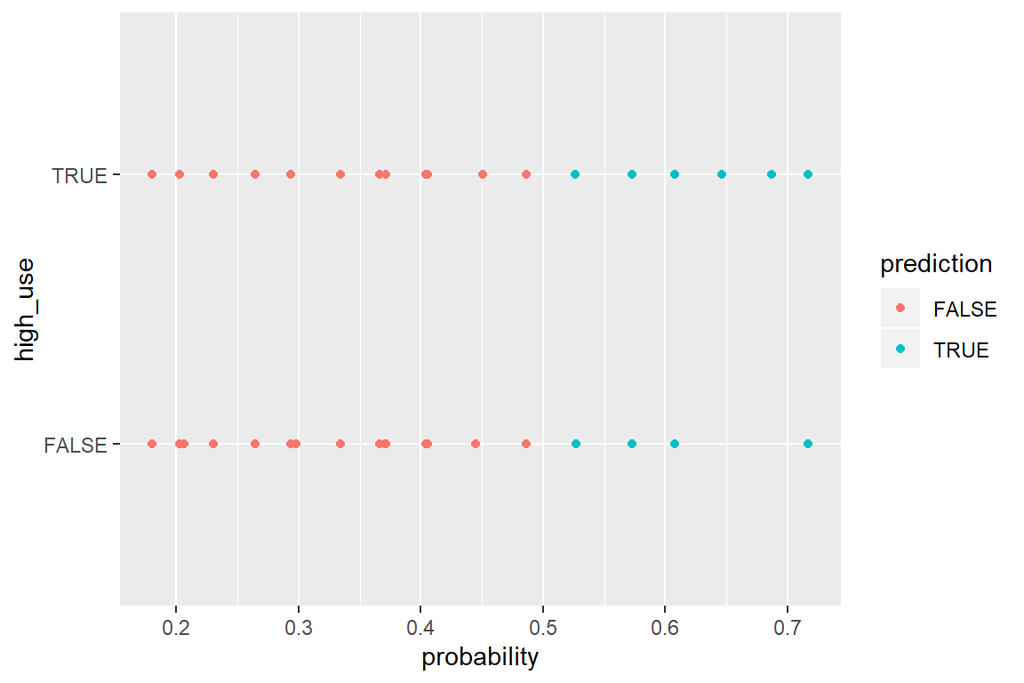

```r
probabilities <- predict(m, type = "response")

alc <- mutate(alc, probability = probabilities)

alc <- mutate(alc, prediction = probabilities > 0.5)

g <- ggplot(alc, aes(x = probability, y = high_use, col = prediction))

g + geom_point()
```

```r
table(high_use = alc$high_use, prediction = alc$prediction) %>% prop.table %>% addmargins
```

```
##         prediction
## high_use      FALSE       TRUE        Sum
##    FALSE 0.68062827 0.02094241 0.70157068
##    TRUE  0.26963351 0.02879581 0.29842932
##    Sum   0.95026178 0.04973822 1.00000000
```

```r
loss_func <- function(class, prob) {
  n_wrong <- abs(class - prob) > 0.5
  mean(n_wrong)
}

loss_func(class = alc$high_use, prob = alc$probability)
```

```
## [1] 0.2905759
```

# Excercise 4

## 1) Create a new Rmarkdown

Created according to instructions as chaper 4

## 2) Loading the data and describing it

```r
install.packages("dplyr", repos="http://cran.us.r-project.org")
```

```r
install.packages("ggplot2", repos="http://cran.us.r-project.org")
install.packages("GGally", repos="http://cran.us.r-project.org")
install.packages("corrplot", repos="http://cran.us.r-project.org")
install.packages("MASS", repos="http://cran.us.r-project.org")
library(ggplot2)
library(GGally)
library(ggplot2)
library(GGally)
library(dplyr)
library(corrplot)
library(MASS)
data("Boston")
summary(Boston)
```

```
##       crim                zn             indus            chas
##  Min.   : 0.00632   Min.   :  0.00   Min.   : 0.46   Min.   :0.00000
##  1st Qu.: 0.08204   1st Qu.:  0.00   1st Qu.: 5.19   1st Qu.:0.00000
##  Median : 0.25651   Median :  0.00   Median : 9.69   Median :0.00000
##  Mean   : 3.61352   Mean   : 11.36   Mean   :11.14   Mean   :0.06917
##  3rd Qu.: 3.67708   3rd Qu.: 12.50   3rd Qu.:18.10   3rd Qu.:0.00000
##  Max.   :88.97620   Max.   :100.00   Max.   :27.74   Max.   :1.00000
##       nox               rm             age              dis
##  Min.   :0.3850   Min.   :3.561   Min.   :  2.90   Min.   : 1.130
##  1st Qu.:0.4490   1st Qu.:5.886   1st Qu.: 45.02   1st Qu.: 2.100
##  Median :0.5380   Median :6.208   Median : 77.50   Median : 3.207
##  Mean   :0.5547   Mean   :6.285   Mean   : 68.57   Mean   : 3.795
##  3rd Qu.:0.6240   3rd Qu.:6.623   3rd Qu.: 94.08   3rd Qu.: 5.188
##  Max.   :0.8710   Max.   :8.780   Max.   :100.00   Max.   :12.127
##       rad              tax           ptratio          black
##  Min.   : 1.000   Min.   :187.0   Min.   :12.60   Min.   :  0.32
##  1st Qu.: 4.000   1st Qu.:279.0   1st Qu.:17.40   1st Qu.:375.38
##  Median : 5.000   Median :330.0   Median :19.05   Median :391.44
##  Mean   : 9.549   Mean   :408.2   Mean   :18.46   Mean   :356.67
##  3rd Qu.:24.000   3rd Qu.:666.0   3rd Qu.:20.20   3rd Qu.:396.23
##  Max.   :24.000   Max.   :711.0   Max.   :22.00   Max.   :396.90
##      lstat            medv
##  Min.   : 1.73   Min.   : 5.00
##  1st Qu.: 6.95   1st Qu.:17.02
##  Median :11.36   Median :21.20
##  Mean   :12.65   Mean   :22.53
##  3rd Qu.:16.95   3rd Qu.:25.00
##  Max.   :37.97   Max.   :50.00
```

The Boston dataset has 506 rows and 14 column variables.

Columns are

**crim**= per capita crime rate by town.**zn**= proportion of residential land zoned for lots over 25,000 sq.ft. **indus** =proportion of non-retail business acres per town. **chas**= Charles River dummy variable (= 1 if tract bounds river; 0 otherwise). **nox**= nitrogen oxides concentration (parts per 10 million). **rm**= average number of rooms per dwelling. **age** =proportion of owner-occupied units built prior to 1940. **dis** =weighted mean of distances to five Boston employment centres. **rad** index of accessibility to radial highways.**tax** =full-value property-tax rate per $10,000. **ptratio** =pupil-teacher ratio by town. **black**= 1000(Bk - 0.63)^2 where Bk is the proportion of blacks by town. **lstat** =lower status of the population (percent). **medv** =median value of owner-occupied homes in $1000s.

## 3) Graphical overview of the data

```r
cor_matrix<-cor(Boston)
cor_matrix%>%round(digits=2)
```

```
##          crim    zn indus  chas   nox    rm   age   dis   rad   tax
## crim     1.00 -0.20  0.41 -0.06  0.42 -0.22  0.35 -0.38  0.63  0.58
## zn      -0.20  1.00 -0.53 -0.04 -0.52  0.31 -0.57  0.66 -0.31 -0.31
## indus    0.41 -0.53  1.00  0.06  0.76 -0.39  0.64 -0.71  0.60  0.72
## chas    -0.06 -0.04  0.06  1.00  0.09  0.09  0.09 -0.10 -0.01 -0.04
## nox      0.42 -0.52  0.76  0.09  1.00 -0.30  0.73 -0.77  0.61  0.67
## rm      -0.22  0.31 -0.39  0.09 -0.30  1.00 -0.24  0.21 -0.21 -0.29
## age      0.35 -0.57  0.64  0.09  0.73 -0.24  1.00 -0.75  0.46  0.51
## dis     -0.38  0.66 -0.71 -0.10 -0.77  0.21 -0.75  1.00 -0.49 -0.53
## rad      0.63 -0.31  0.60 -0.01  0.61 -0.21  0.46 -0.49  1.00  0.91
## tax      0.58 -0.31  0.72 -0.04  0.67 -0.29  0.51 -0.53  0.91  1.00
## ptratio  0.29 -0.39  0.38 -0.12  0.19 -0.36  0.26 -0.23  0.46  0.46
## black   -0.39  0.18 -0.36  0.05 -0.38  0.13 -0.27  0.29 -0.44 -0.44
## lstat    0.46 -0.41  0.60 -0.05  0.59 -0.61  0.60 -0.50  0.49  0.54
## medv    -0.39  0.36 -0.48  0.18 -0.43  0.70 -0.38  0.25 -0.38 -0.47
##         ptratio black lstat  medv
## crim       0.29 -0.39  0.46 -0.39
## zn        -0.39  0.18 -0.41  0.36
## indus      0.38 -0.36  0.60 -0.48
## chas      -0.12  0.05 -0.05  0.18
## nox        0.19 -0.38  0.59 -0.43
## rm        -0.36  0.13 -0.61  0.70
## age        0.26 -0.27  0.60 -0.38
## dis       -0.23  0.29 -0.50  0.25
## rad        0.46 -0.44  0.49 -0.38
## tax        0.46 -0.44  0.54 -0.47
## ptratio    1.00 -0.18  0.37 -0.51
## black     -0.18  1.00 -0.37  0.33
## lstat      0.37 -0.37  1.00 -0.74
## medv      -0.51  0.33 -0.74  1.00
```

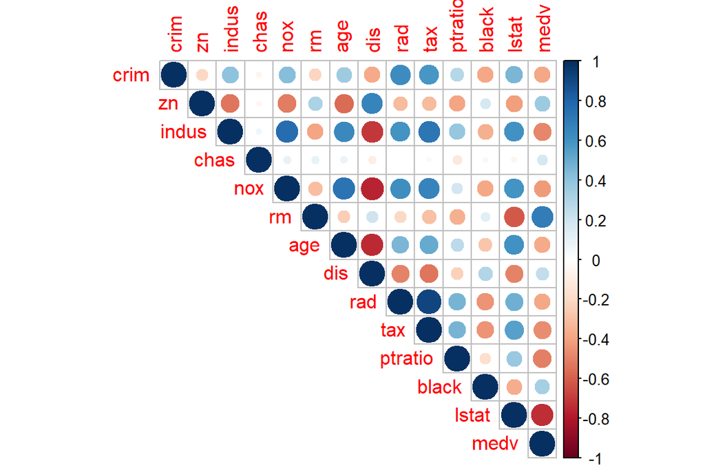

```r
corrplot(cor_matrix, method="circle", type="upper")
```

From the corrplot picture we can see which variables have correlations with each others. We can see that for example the distance of five employement centers in boston have a high correlation with proportion of non-retail bussiness acres per town. And that average number of rooms per dwelling is negatively linked to lower status of the population percent.

## 4) Standardizing the data

```r
boston_scaled <- scale(Boston)
class(boston_scaled)
```

```
## [1] "matrix"
```

```r
boston_scaled <- as.data.frame(boston_scaled)

bins <- quantile(boston_scaled$crim)
bins
```

```
##           0%          25%          50%          75%         100%
## -0.419366929 -0.410563278 -0.390280295  0.007389247  9.924109610
```

```r
crime <- cut(boston_scaled$crim, breaks = bins, labels = c("low", "med_low","med_high", "high") , include.lowest = TRUE)

table(crime)
```

```
## crime
##      low  med_low med_high     high
##      127      126      126      127
```

```r
boston_scaled <- dplyr::select(boston_scaled, -crim)
boston_scaled <- data.frame(boston_scaled, crime)
n <- nrow(boston_scaled)
ind <- sample(n,  size = n * 0.8)
train <- boston_scaled[ind,]
test <- boston_scaled[-ind,]
correct_classes <- test$crime
test <- dplyr::select(test, -crime)
```

Now the crime variable is set to 4 categories according to how high is the per capita crime rate by town.

## 5) Linear discriminant analysis

```r
lda.fit <- lda(crime ~ ., data = train)
lda.fit
```

```
## Call:
## lda(crime ~ ., data = train)
##
## Prior probabilities of groups:
##       low   med_low  med_high      high
## 0.2599010 0.2475248 0.2326733 0.2599010
##
## Group means:
##                  zn      indus        chas        nox         rm
## low       0.9462854 -0.9059533 -0.15984049 -0.8766372  0.4381224
## med_low  -0.1071344 -0.2436432 -0.07547406 -0.5702225 -0.1612747
## med_high -0.3586088  0.1144300  0.14651138  0.3456198  0.1593642
## high     -0.4872402  1.0170492 -0.04735191  1.0473293 -0.4020697
##                 age        dis        rad        tax     ptratio
## low      -0.8750974  0.8783980 -0.6963951 -0.7338161 -0.42113026
## med_low  -0.3800119  0.4151717 -0.5443053 -0.4715706 -0.09632279
## med_high  0.3983984 -0.3727585 -0.4125248 -0.3391066 -0.30377728
## high      0.7937851 -0.8472617  1.6388211  1.5145512  0.78158339
##               black       lstat        medv
## low       0.3770740 -0.75815278  0.49027372
## med_low   0.3435918 -0.10681371 -0.03303282
## med_high  0.0999906 -0.03260726  0.23320963
## high     -0.8234483  0.90009075 -0.68204146
##
## Coefficients of linear discriminants:
##                 LD1         LD2         LD3
## zn       0.05018847  0.71929583 -0.98690469
## indus    0.01763364 -0.18606403  0.47558140
## chas    -0.06014011 -0.09204451  0.04743685
## nox      0.33087648 -0.81283553 -1.24575571
## rm      -0.09063907 -0.09805920 -0.15173624
## age      0.21203758 -0.28584102 -0.17409724
## dis     -0.11260556 -0.24367315  0.40232534
## rad      3.14205601  0.86821812  0.06127230
## tax      0.01712966  0.07661956  0.40619316
## ptratio  0.07149844  0.04272586 -0.36992343
## black   -0.11700743  0.01248913  0.16440573
## lstat    0.23163582 -0.21996957  0.44507940
## medv     0.17899892 -0.36873990 -0.13638845
##
## Proportion of trace:
##    LD1    LD2    LD3
## 0.9492 0.0355 0.0153
```

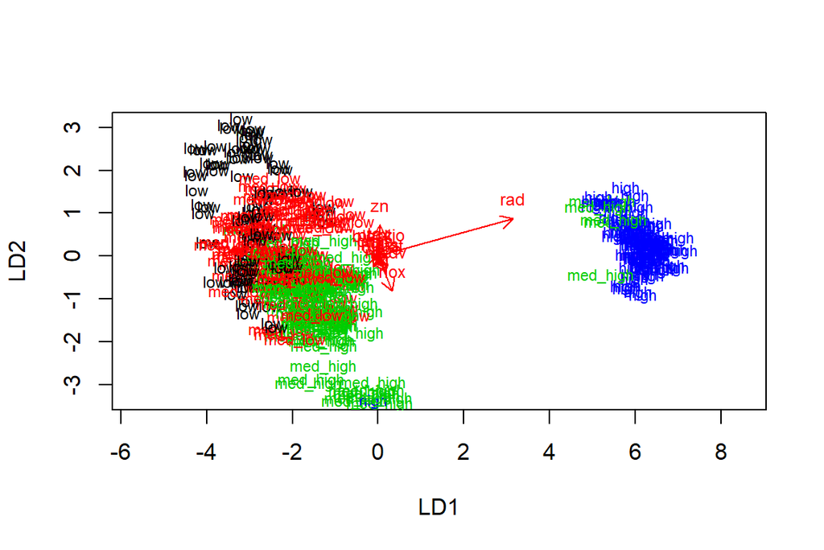

```r
lda.arrows <- function(x, myscale = 1, arrow_heads = 0.1, color = "red", tex = 0.75, choices = c(1,2)){
  heads <- coef(x)
  arrows(x0 = 0, y0 = 0,
         x1 = myscale * heads[,choices[1]],
         y1 = myscale * heads[,choices[2]], col=color, length = arrow_heads)
  text(myscale * heads[,choices], labels = row.names(heads),
       cex = tex, col=color, pos=3)
}

classes <- as.numeric(train$crime)
plot(lda.fit, dimen = 2, col = classes, pch = classes)
lda.arrows(lda.fit, myscale = 1)
```

In the above picture we can see the linear combination of the variables that separate the crime classes. The LDA model os visualized as a biplot

## 6) Predicting classes

```r
lda.pred <- predict(lda.fit, newdata = test)
table(correct = correct_classes, predicted = lda.pred$class)
```

```
##           predicted
## correct    low med_low med_high high
##   low       12       8        2    0
##   med_low    5      11       10    0
##   med_high   0       7       24    1
##   high       0       0        0   22
```